# RF, DDPM, and DDIM on Gaussian Mixtures

Theory, implementation map, and controlled experiments

## What this compares

Rectified Flow (RF), respaced DDPM, and deterministic DDIM, run against Gaussian mixtures where exact samples are available as ground truth.

Everything that could confound the comparison is held fixed. Same network shape and width, same 3,000 optimizer updates, same initial noise tensor, same 5,000 evaluation samples, same NFE budget. What varies is the sampler and the geometry of the target. DDPM and DDIM always share one trained noise model, so any gap between those two is a sampler effect and nothing else.

**NoteEvidence status**

Every table below is pinned by the experiment entrypoints against reference values at six decimal places, so code drift fails the run instead of quietly changing a number. All runs are CPU, PyTorch 2.13.0, Python 3.12.13.

The four-size, three-seed finite-data extension has been run. Its summary values are frozen as a regression check at six decimal places, with raw replicate rows in `results/tables/sample_size_replication_raw.csv`.

## Target distributions

The isotropic target is an equally weighted mixture

$$p(x)=\frac{1}{K}\sum_{k=1}^{K}\mathcal{N}(x;\mu_k,\sigma^2 I),$$

with eight means on a circle in the first two coordinates. The 32-dimensional target keeps those same mode-bearing coordinates and adds 30 more whose component means are all zero.

For the anisotropic target the component noise is aligned with the radial and tangential directions:

$$\epsilon_k=\sigma_r z_r e_{r,k}+\sigma_t z_t e_{t,k}.$$

The tested standard-deviation pairs are $(0.60,0.15)$ and $(0.90,0.10)$. Both hold $\sigma_r\sigma_t=0.09$, which matches the isotropic scale $0.30^2$.

That fixes the determinant, not the spread. Total variance still climbs from 0.18 in the isotropic case to 0.3825 and then 0.82, so anything that gets harder across these three targets mixes two effects, shape and size. Reading the anisotropy sweeps as a pure shape result would overclaim. A fixed-trace variant would separate them.

Code lives in `src/gmm.py`.

## Rectified Flow

RF trains a velocity field on straight interpolation pairs:

$$x_t=(1-t)x_0+tx_1,
\qquad
v_{\mathrm{target}}=x_1-x_0.$$

Sampling is forward Euler:

$$x_{k+1}=x_k+\Delta t\,v_\theta(x_k,t_k).$$

Code lives in `src/rectified_flow.py`.

## DDPM and DDIM

The forward diffusion marginal is

$$q(x_t\mid x_0)=
\mathcal{N}\left(
\sqrt{\bar\alpha_t}x_0,
(1-\bar\alpha_t)I
\right).$$

The clean-sample estimate is

$$\hat{x}_0=
\frac{x_t-\sqrt{1-\bar\alpha_t}\,\epsilon_\theta(x_t,t/T)}
{\sqrt{\bar\alpha_t}}.$$

DDPM samples from the jump posterior induced by $q(x_t\mid x_s)$ rather than repeating adjacent-step coefficients over a stride. DDIM walks the same timetable with $\eta=0$. Running fewer steps always means subsampling the one trained $T=300$ model, never retraining at a smaller $T$, so NFE is a sampling budget rather than a different model.

Two details in this section are easy to get wrong and produce output that still looks plausible.

The beta schedule is linear and scaled by $1000/T$, which puts terminal $\bar\alpha$ at $3.4\times10^{-5}$. The textbook range 1e-4 to 0.02 assumes $T=1000$. Dropped onto $T=300$ unchanged it leaves $\bar\alpha_T\approx0.048$, meaning the forward process stops well short of the $\mathcal{N}(0,I)$ that sampling starts from. With modes at radius 4 that leaves roughly 0.9 of surviving signal, and the resulting prior mismatch would show up as a DDPM and DDIM error floor that RF does not have. Easy to misread as a method difference.

Under respacing the model is fed the original timestep $t/T$, never its position $k/K$ in the shortened schedule. Both samplers are checked for this.

Code lives in `src/diffusion.py`.

## Evaluation protocol

Sampling quality is measured by Sliced Wasserstein Distance:

$$\operatorname{SWD}(X,Y)
=
\mathbb{E}_{\theta}
\left[
W_1(\theta^\top X,\theta^\top Y)
\right].$$

At every condition and NFE the three methods start from the same Gaussian noise, and the SWD projection seed is reset immediately before each call so they are scored against the same random directions. At NFE 1 DDPM and DDIM reduce to the same one-shot estimate, so their samples must come out identical. Every experiment asserts that, which is what caught a projection-desync bug during the original implementation.

Code lives in `src/metrics.py`, with figure styling isolated in `src/plotting.py`.

## Two-dimensional baseline

| Method | NFE 1 | NFE 5 | NFE 20 | NFE 100 |
| --- | --- | --- | --- | --- |
| RF | 2.466272 | 0.229457 | 0.089896 | 0.072012 |
| DDPM | 7.821843 | 0.383462 | 0.149218 | 0.111276 |
| DDIM | 7.821843 | 0.790958 | 0.298274 | 0.227991 |

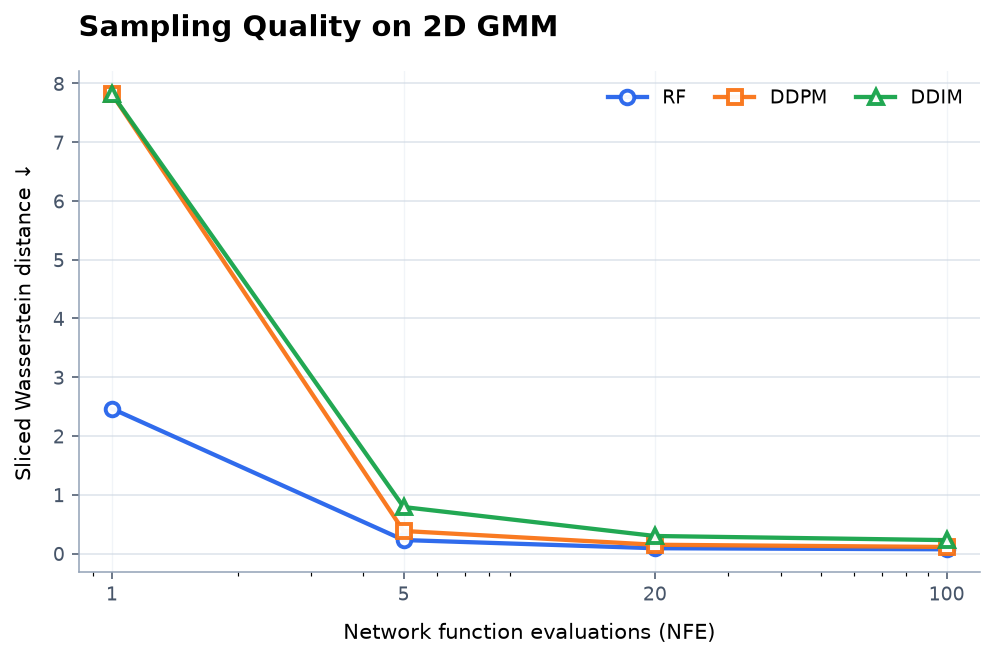

SWD against NFE on the 2D eight-mode target.

RF has the lowest SWD at every tested NFE. One target, one training budget, one seed protocol, so this is a measurement rather than a ranking of the methods.

One bookkeeping note for anyone holding earlier figures. An earlier version of this experiment reported RF at roughly 2.4, 0.12 and 0.11 for 1, 20 and 100 steps. The current pipeline gives 2.466, 0.090 and 0.072 on the same target. The numbers above are the ones the current regression assertions reproduce, and they are what should be quoted going forward. The earlier values predate the current pipeline and have not been traced back to a specific change, so the difference is recorded here rather than explained.

DDIM trails DDPM at every budget above a single evaluation, which runs against the usual expectation that the deterministic sampler does better when steps are scarce. One candidate explanation is that with an imperfect noise model the ancestral noise acts as a correction rather than a nuisance. That is a hypothesis. Nothing here tests it, and it is the first thing worth checking against an oracle score.

## Thirty-two-dimensional baseline

| Method | NFE 1 | NFE 5 | NFE 20 | NFE 100 |
| --- | --- | --- | --- | --- |
| RF | 0.494065 | 0.073598 | 0.028437 | 0.023310 |
| DDPM | 7.725866 | 0.129679 | 0.059936 | 0.041134 |
| DDIM | 7.725866 | 0.108869 | 0.049766 | 0.045006 |

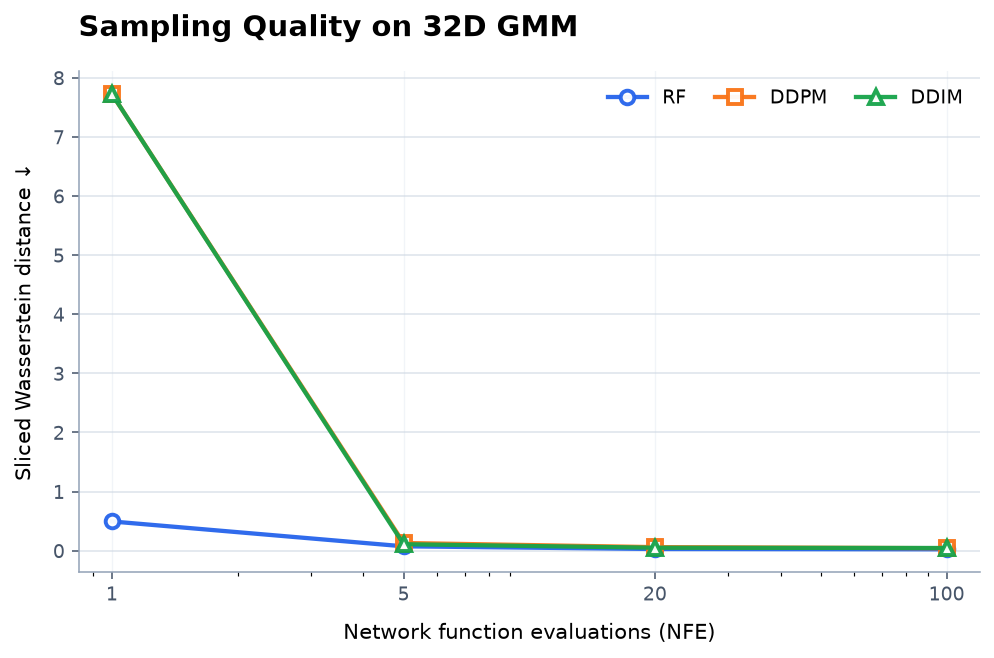

SWD against NFE on the 32D target.

The 32D numbers are not on the same scale as the 2D ones and should not be compared across sections. Thirty of the thirty-two coordinates carry no mode information, so a random projection mostly measures shared isotropic noise and dilutes whatever error sits on the two coordinates that actually separate the modes. A coordinate-specific metric alongside the all-coordinate SWD would settle how much is being hidden.

Note also that DDIM beats DDPM at NFE 5 and 20 here, reversing the 2D ordering. Single seed, so this is an observation to replicate, not a dimension effect.

## Anisotropic components

The exploratory seed-17 run showed a narrow DDPM advantage at NFE 100. It did not survive averaging over three seeds, which is the reason the single-seed tables are not reported as findings.

### Anisotropy ratio 4, mean SWD over three seeds (± sample standard deviation)

| Method | NFE 1 | NFE 5 | NFE 20 | NFE 100 |
| --- | --- | --- | --- | --- |
| RF | 2.403939 ± 0.031688 | 0.372198 ± 0.045335 | 0.129051 ± 0.049528 | 0.091553 ± 0.033182 |
| DDPM | 5.989495 ± 1.768162 | 0.550494 ± 0.176919 | 0.242296 ± 0.044962 | 0.190362 ± 0.060847 |
| DDIM | 5.989495 ± 1.768162 | 0.639427 ± 0.308017 | 0.307871 ± 0.189285 | 0.276230 ± 0.124771 |

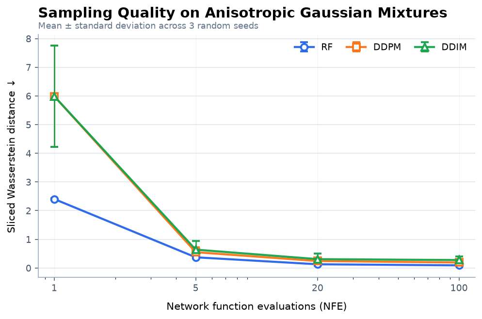

Anisotropy ratio 4, mean and standard deviation across three seeds.

### Anisotropy ratio 9, mean SWD over three seeds (± sample standard deviation)

| Method | NFE 1 | NFE 5 | NFE 20 | NFE 100 |
| --- | --- | --- | --- | --- |
| RF | 2.415093 ± 0.048752 | 0.503868 ± 0.049270 | 0.164355 ± 0.042226 | 0.104576 ± 0.031979 |
| DDPM | 5.589503 ± 0.457367 | 0.629097 ± 0.110569 | 0.246952 ± 0.102339 | 0.184829 ± 0.066172 |
| DDIM | 5.589503 ± 0.457367 | 0.688808 ± 0.205660 | 0.291196 ± 0.181392 | 0.234896 ± 0.165471 |

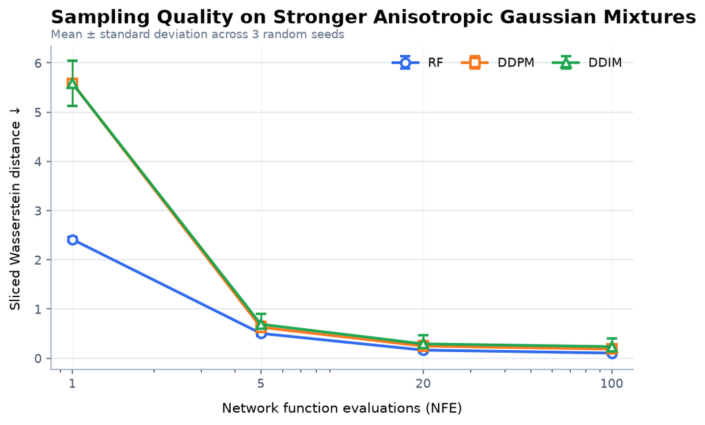

Anisotropy ratio 9, mean and standard deviation across three seeds.

The evidence covers two 2D covariance ratios and three training seeds, nothing wider. And per the caveat above, the two ratios differ in total variance as well as in shape, so the drop in RF quality from ratio 4 to ratio 9 cannot be attributed to anisotropy alone.

## Finite training data and mode separation

The original finite-data experiment covered two training sizes, 500 and 5,000, with one training seed each. Those rows remain useful historical exploratory results, but they are superseded for inference by the four-size, three-seed replication below.

### Exploratory SWD, training size 500 (one training seed)

| Method | NFE 1 | NFE 5 | NFE 20 | NFE 100 |
| --- | --- | --- | --- | --- |
| RF | 2.428478 | 0.228450 | 0.125386 | 0.114582 |
| DDPM | 7.041986 | 0.321739 | 0.241869 | 0.246561 |
| DDIM | 7.041986 | 0.702271 | 0.350256 | 0.319216 |

### Exploratory SWD, training size 5,000 (one training seed)

| Method | NFE 1 | NFE 5 | NFE 20 | NFE 100 |
| --- | --- | --- | --- | --- |
| RF | 2.440729 | 0.236065 | 0.099100 | 0.079427 |
| DDPM | 4.651069 | 0.304992 | 0.151924 | 0.117697 |
| DDIM | 4.651069 | 0.493269 | 0.250375 | 0.212694 |

### Replicated finite-data SWD, four training sizes and three seeds (mean ± sample standard deviation)

Each `(training size, seed)` condition has its own immutable finite dataset. The datasets are independent across sizes, rather than nested prefixes. RF and diffusion train on the same dataset within a condition; evaluation uses shared initial noise and shared SWD projections. Replication labels are 201, 202, and 203.

| Train size | Method | NFE 1 | NFE 5 | NFE 20 | NFE 100 |
| --- | --- | --- | --- | --- | --- |
| 500 | RF | 2.379848 ± 0.031706 | 0.286507 ± 0.075844 | 0.180010 ± 0.057540 | 0.172630 ± 0.057892 |
| 500 | DDPM | 7.005083 ± 1.508816 | 0.337694 ± 0.073639 | 0.187188 ± 0.067244 | 0.193947 ± 0.083172 |
| 500 | DDIM | 7.005083 ± 1.508816 | 0.587400 ± 0.207704 | 0.274808 ± 0.092813 | 0.233184 ± 0.078619 |
| 1,000 | RF | 2.417506 ± 0.017833 | 0.282808 ± 0.051359 | 0.169696 ± 0.058871 | 0.164657 ± 0.068112 |
| 1,000 | DDPM | 8.810027 ± 0.615799 | 0.597845 ± 0.129757 | 0.265684 ± 0.133603 | 0.281360 ± 0.109509 |
| 1,000 | DDIM | 8.810027 ± 0.615799 | 1.015912 ± 0.219206 | 0.485077 ± 0.128275 | 0.409522 ± 0.124196 |
| 2,500 | RF | 2.426983 ± 0.010768 | 0.270155 ± 0.029752 | 0.180096 ± 0.019716 | 0.172118 ± 0.021134 |
| 2,500 | DDPM | 5.565868 ± 3.902343 | 0.425934 ± 0.026825 | 0.212537 ± 0.082096 | 0.165671 ± 0.054554 |
| 2,500 | DDIM | 5.565868 ± 3.902343 | 0.708243 ± 0.303890 | 0.363435 ± 0.083882 | 0.309159 ± 0.072598 |
| 5,000 | RF | 2.443599 ± 0.019639 | 0.258057 ± 0.016398 | 0.134630 ± 0.016587 | 0.121576 ± 0.019739 |
| 5,000 | DDPM | 4.527358 ± 1.038122 | 0.244517 ± 0.041107 | 0.102525 ± 0.035969 | 0.102183 ± 0.002607 |
| 5,000 | DDIM | 4.527358 ± 1.038122 | 0.510324 ± 0.113447 | 0.190603 ± 0.061505 | 0.150663 ± 0.038645 |

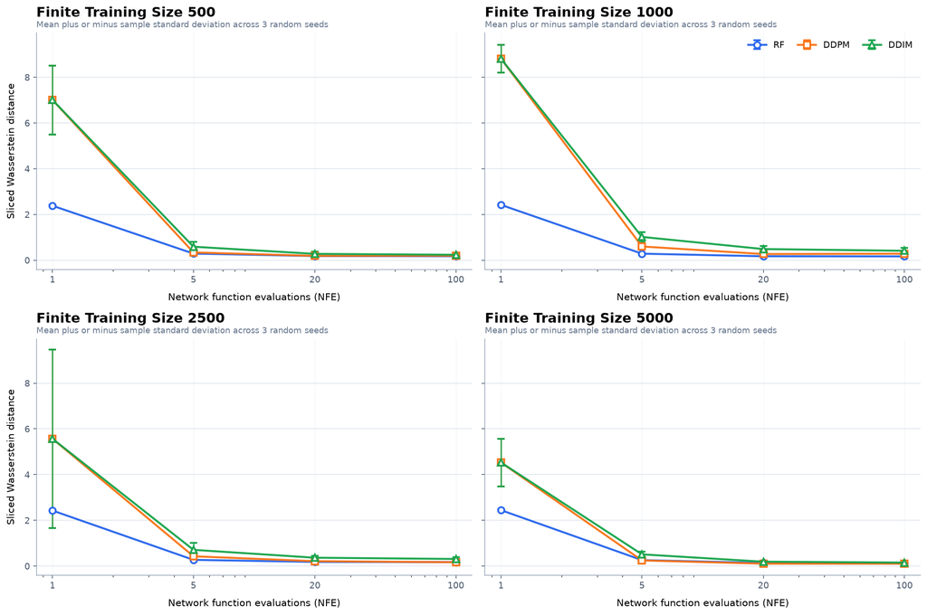

Finite-data replication across four training sizes, mean and sample standard deviation over three seeds.

RF has the lowest mean SWD at NFE 1 for every training size. At higher NFE, RF is lowest at all four budgets for sizes 500 and 1,000, while DDPM has the lower mean at NFE 100 for size 2,500 and at NFE 5, 20, and 100 for size 5,000. Several gaps overlap their three-seed standard deviations, so this does not establish a monotone training-size effect or a general sampler ordering. It does establish that the old two-point, one-seed pattern was too weak to support either claim.

The NFE 1 column should be read the same way as in the mode-separation tables: the diffusion means move non-monotonically with size (7.0, 8.8, 5.6, 4.5) with standard deviations up to 3.9, so that column is dominated by training-seed variation, not by the training size.

One pattern worth flagging as a hypothesis rather than a finding. The online-sampler 2D baseline, which is effectively unlimited training data, put RF at 0.072 and DDPM at 0.111 at NFE 100. In this finite-data table at size 5,000, DDPM sits at 0.102 ± 0.003, close to its online value, while RF sits at 0.122 ± 0.020, well above its own. Read at face value that says DDPM has roughly saturated by 5,000 training points on this target while RF is still data-hungry, and it would explain why the sampler ordering flips at the larger sizes. The comparison is not controlled, though: the online baseline is a single seed and uses different evaluation streams, so this needs a dedicated online-vs-finite run before it is more than a lead.

Mode separation was replicated across seeds 29, 30 and 31, holding everything fixed except the ring radius.

### Mode radius 1.5, mean SWD over three seeds (± sample standard deviation)

| Method | NFE 1 | NFE 5 | NFE 20 | NFE 100 |
| --- | --- | --- | --- | --- |
| RF | 0.933534 ± 0.003858 | 0.132098 ± 0.013956 | 0.050159 ± 0.011258 | 0.039630 ± 0.005568 |
| DDPM | 3.719933 ± 0.889634 | 0.256067 ± 0.014398 | 0.074307 ± 0.013896 | 0.042471 ± 0.007520 |
| DDIM | 3.719933 ± 0.889634 | 0.238849 ± 0.038390 | 0.090493 ± 0.011111 | 0.076324 ± 0.022629 |

### Mode radius 6.0, mean SWD over three seeds (± sample standard deviation)

| Method | NFE 1 | NFE 5 | NFE 20 | NFE 100 |
| --- | --- | --- | --- | --- |
| RF | 3.466497 ± 0.011871 | 0.305740 ± 0.023525 | 0.175333 ± 0.042383 | 0.165554 ± 0.040958 |
| DDPM | 6.968878 ± 3.507420 | 0.681356 ± 0.114742 | 0.329471 ± 0.077847 | 0.282831 ± 0.030777 |
| DDIM | 6.968878 ± 3.507420 | 0.975413 ± 0.473165 | 0.415965 ± 0.096054 | 0.359946 ± 0.061186 |

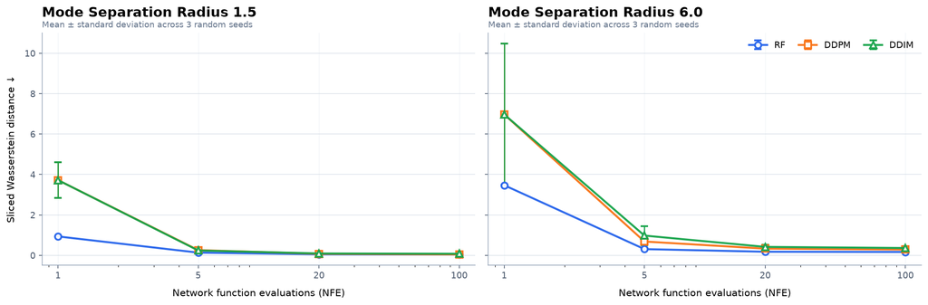

Mode-separation replication at radius 1.5 and 6.0, three seeds.

RF has the lowest mean SWD at both radii and every NFE. This is the one place a crossing appeared in earlier work. At radius 6.0 with a single seed, DDPM came in ahead of RF at NFE 20 and 100, and it disappeared under averaging. Worth remembering when reading any single-seed table in this project.

Read the spreads before the means. At radius 1.5 and NFE 100, RF and DDPM sit at 0.0396 and 0.0425 with standard deviations of 0.0056 and 0.0075, so those two are not separated by three seeds. The NFE 1 column is worse still: the diffusion pair carries a standard deviation of 3.5 at radius 6.0, larger than most of the means elsewhere in the table. That column says almost nothing beyond “one evaluation is not enough”, and the seed-to-seed variation there comes from training, since at NFE 1 both samplers are deterministic given the shared noise.

## Reproducing the experiments

From the project root:

```
python -m experiments.baseline_2d
python -m experiments.high_dim
python -m experiments.anisotropic
python -m experiments.robustness
```

Each entrypoint writes CSV tables to `results/tables/`, figures to `results/figures/`, and checks its SWD values against pinned reference values at six decimal places. Timing columns are recorded but not asserted, since wall-clock depends on the machine. The full set takes roughly half an hour on CPU, dominated by the robustness sweep, which now trains 40 models.

## Next experiment

The four-size finite-data replication is complete, which closes the weakest gap in the earlier version of this report. Three controls now compete for the next slot.

An oracle score, computed analytically from the known mixture, would separate sampler and geometry effects from learned-field error. It bears on two open observations at once: whether the DDIM behaviour at low NFE is a real sampler property or an artifact of this training budget, and whether the sampler-ordering flip at large training sizes is a sampler effect or a learning effect. A coordinate-specific metric would say how much the 32D result is hiding. A fixed-trace anisotropy factorial would separate covariance shape from total variance in the anisotropic sweeps.

Everything here is a measurement on toy targets where the ground truth is known. That is the point of the setup, and also the limit of what it can claim.